# Pre-processing ASVs with Phyloseq

Chloe J McGovern

2025-03-25

## Goals

First, we will use the phyloseq package to combine all of the data objects that we exported from the DADA2 workflow (`asv_table`, `tax_table`, and `metadata`) and incorporate them into a single specialized S4 R Data object, known as a phyloseq object. Then, we will remove any potential contaminants and evaluate the accuracy of our sequencing run. Finally, we will write our our single `raw_preprocessed_physeq` phyloseq data object.

## Specific Steps:

1. Load in data that we’ve generated in `analysis/02_AssignASVs.Rmd` and fix all of the names to match each other. *The names must match for us to incorporate them into the S4 phyloseq object*:
   1. `asv_table`: ASVs (rows) x Samples (columns)
   2. `tax_table`: ASV (rows) x Taxonomy (columns)
   3. `metadata`: Samples (rows) x All our data (*e.g. pH, Temp, treatment group, etc*; columns)
2. Combine the data into a phyloseq object.
3. Remove any contaminating ASVs that are **chloroplasts**.
4. Remove ASVs that are **mitochondria**.
5. Evaluate any ASVs from the **negative controls**. Then, remove negative controls.
6. Evaluate the mock community or **positive control** to learn the accuracy of sequencing.
7. Check for **reverse complements**.
8. Check the **sequencing depth** of samples. Remove samples that obviously have too few reads.
9. Write a `raw_preprocessed_physeq` to be used in the next step of our workflow.

## Output

1. A **pre-processed S4 phyloseq object**: `raw_preprocessed_physeq.RData`.

# Set Environment

## Load Packages

```r
#install.packages("BiocManager")
#BiocManager::install("Biostrings")

#install.packages("ggpubr")
#install.packages("rstatix")

# Load packages
pacman::p_load(devtools, phyloseq, dada2, patchwork, Biostrings, tidyverse,
               ggpubr, rstatix, install = FALSE)
```

## Timing of this script

Let’s record how long this file took to run on the class server, which we will record at the end of the script.

```r
# What time did we start running this script?
start_time <- Sys.time()
```

## 1. Load Data

### 1a. Metadata

Here, we will load in our **metadata** files, which include:

1. `data/metadata.csv`: This file contains all of our samples and also any measured variables, including station, date of collection, depth of sample, temperature, pH, salinity, etc.
2. `data/01_DADA2/track_read_counts.RData`: This file contains how many reads we maintained in our samples through the DADA2 workflow.

```r
# load in metadata
metadata_df <-
  read_csv("data/metadata.csv") %>%
  # Fix Column Name
  dplyr::rename("sample_names" = "Run") %>%
  # Add sample names also as a column
  mutate(names = sample_names)
# Inspect
head(metadata_df)
```

```
## # A tibble: 6 × 41
##   sample_names `Assay Type` AvgSpotLen    Bases BioProject  BioSample
##   <chr>        <chr>             <dbl>    <dbl> <chr>       <chr>
## 1 SRR9722160   AMPLICON            501 26751772 PRJNA555359 SAMN12315521
## 2 SRR9722161   AMPLICON            501 48509001 PRJNA555359 SAMN12315522
## 3 SRR9722162   AMPLICON            501 44920611 PRJNA555359 SAMN12315523
## 4 SRR9722163   AMPLICON            501 41740908 PRJNA555359 SAMN12315524
## 5 SRR9722164   AMPLICON            501 51591656 PRJNA555359 SAMN12315511
## 6 SRR9722165   AMPLICON            501 47588893 PRJNA555359 SAMN12315512
## # ℹ 35 more variables: BioSampleModel <chr>, Bytes <dbl>, `Center Name` <chr>,
## #   cheese_id <dbl>, Collection_Date <date>, Consent <chr>, Cultivar <chr>,
## #   `DATASTORE filetype` <chr>, `DATASTORE provider` <chr>,
## #   `DATASTORE region` <chr>, Ecotype <chr>, env_broad_scale <chr>,
## #   env_local_scale <chr>, env_medium <chr>, Experiment <chr>,
## #   geo_loc_name_country <chr>, geo_loc_name_country_continent <chr>,
## #   geo_loc_name <chr>, Instrument <chr>, isol_growth_condt <chr>, …
```

```r
dim(metadata_df)
```

```
## [1] 20 41
```

```r
# include dada2 output
load("data/01_DADA2/track_read_counts.RData")

# Take a look
glimpse(track_counts_df)
```

```
## Rows: 20
## Columns: 6
## $ sample_names <chr> "SRR9722160_R1_filtered.fastq.gz", "SRR9722161_R1_filtere…
## $ denoisedF    <dbl> 37768, 69666, 66228, 63580, 75813, 68080, 63976, 57883, 1…
## $ denoisedR    <dbl> 37746, 69661, 66215, 63583, 75711, 68056, 63980, 57882, 1…
## $ merged       <dbl> 35735, 64550, 61871, 60217, 70917, 63376, 60678, 54360, 9…
## $ nochim       <dbl> 32004, 58676, 56254, 53609, 66632, 60147, 53177, 53007, 9…
## $ num_ASVs     <dbl> 9, 12, 9, 14, 19, 19, 10, 9, 20, 20, 8, 36, 35, 14, 13, 1…
```

```r
dim(track_counts_df)
```

```
## [1] 20  6
```

```r
# Check filenames
head(track_counts_df$sample_names)
```

```
## [1] "SRR9722160_R1_filtered.fastq.gz" "SRR9722161_R1_filtered.fastq.gz"
## [3] "SRR9722162_R1_filtered.fastq.gz" "SRR9722163_R1_filtered.fastq.gz"
## [5] "SRR9722164_R1_filtered.fastq.gz" "SRR9722165_R1_filtered.fastq.gz"
```

```r
# Fix sample names in track_reads
track_counts_df$sample_names <- sapply(strsplit(track_counts_df$sample_names, "_"), `[`, 1)

# Intuition check
head(track_counts_df$sample_names)
```

```
## [1] "SRR9722160" "SRR9722161" "SRR9722162" "SRR9722163" "SRR9722164"
## [6] "SRR9722165"
```

```r
# What's different?
setdiff(track_counts_df$sample_names, metadata_df$sample_names) #yay! passed go!
```

```
## character(0)
```

```r
# Let's do a filtering join with left_join
metadata_final_df <-
  metadata_df %>%
  left_join(., track_counts_df, by = "sample_names") %>%
  # sample names to the rownames to merge into phyloseq
  column_to_rownames(var = "sample_names")

# Check
dim(metadata_final_df)
```

```
## [1] 20 45
```

## 1b. ASV Tables

Load in the ASV count table that we created within DADA2 in `analysis/02_AssignASVs.Rmd`.

```r
asv_df <-
  read.delim(file = "data/01_DADA2/ASV_table.tsv", sep = "\t",
           header = TRUE, row.names = 1)

# Inspect
asv_df[1:3, 1:3]
```

```
##          SRR9722160 SRR9722161 SRR9722162
## ASV_0001      29902      50514      51179
## ASV_0002       1149       6390       3598
## ASV_0003         16         45         43
```

Since samples do not start with numbers I do not need to change the sample names for better R understanding.

## 1c. Taxonomy Table

Let’s also load the taxonomy table that we created in `analysis/02_AssignASVs.Rmd`.

```r
tax_df <-
  read.delim("data/01_DADA2/ASV_taxonomy.tsv", sep = "\t",
           header = TRUE, row.names = 1)

# Inspect
dim(tax_df)
```

```
## [1] 93  9
```

```r
dim(asv_df) # yay! they match
```

```
## [1] 93 20
```

```r
# Double checking using code (no human error)
stopifnot(rownames(asv_df) == rownames(tax_df)) #no news is good news
```

# 2. Handoff to phyloseq

This is where I will combine my `metadata`, `asv count table`, and `taxonomy table` into a single data S4 data object in R, which will be called `raw_physeq` for now.

```r
raw_physeq <-
  phyloseq(otu_table(asv_df, taxa_are_rows = TRUE),
         sample_data(metadata_final_df),
         tax_table(as.matrix(tax_df)))

# Check out
raw_physeq
```

```
## phyloseq-class experiment-level object
## otu_table()   OTU Table:         [ 93 taxa and 20 samples ]
## sample_data() Sample Data:       [ 20 samples by 45 sample variables ]
## tax_table()   Taxonomy Table:    [ 93 taxa by 9 taxonomic ranks ]
```

```r
# save
save(raw_physeq, file = "data/03_PreProcessing/raw_physeq.RData")
```

# Now it is time to clean the data!

Chloroplasts and mitochondria need to be removed from 16S datasets because they contain their own 16S rRNA genes, which are evolutionarily derived from bacteria. These organelles can be unintentionally amplified during PCR, especially in samples from plants (chloroplasts) or animals (mitochondria), leading to misleading results by inflating microbial diversity.

# 3. Remove chloroplasts

```r
noChloros_physeq <-
  raw_physeq %>%
  subset_taxa(Order != "Chloroplast" | is.na(Order))

# How many ASVs were chloroplasts?
numChloros_ASVs <- ntaxa(raw_physeq) - ntaxa(noChloros_physeq)
```

There were 0 chloroplasts.

# 4. Mitochondria

```r
noChlorosMitos_physeq <-
  noChloros_physeq %>%
  subset_taxa(Family != "Mitochondria" | is.na(Family))

# How many ASVs were mitochondria?
numMitos_ASVs <- ntaxa(noChloros_physeq) - ntaxa(noChlorosMitos_physeq)
```

There were 0 mitochondrias.

How many chloroplast and/or mitochondrial ASVs in your dataset? Does this seem reasonable?

There were no chloroplasts or mitochondria cleaned from the sequencing data! This at first made sense if they cultured the bacteria on plates and then did the DNA extraction from a pellet of cells. To confirm this thought, I went back to the manuscript I am re-analyzing and it turns out they did not culture the bacteria. Rather there was 100 g of cheese samples homogenized in water, filtered with a sieve and gauze, then centrifuged. The pellet was diluted and aliquoted for DNA extraction.

This method would likely retain intact microbial cells, fat/protein matrix fragments, and even some host-derived (milk) material.

So I continued reading in the manuscript when I caught this sentence: “F515 and R806 primers, both modified to contain an Illumina adapter region”. It turns out they cited a paper in `2.4. Library preparation and 16S rRNA sequencing` section, Caporaso, et al., 2011, where they used primers that suppress non-bacterial amplification.

Overall, this would mean that 0 chloroplasts and mitochondria detected was not a mistake but rather an expected result based on the primer design.

# 5. Remove controls

Did your dataset have any negative controls? If so, how many ASVs did you remove? Does that seem reasonable to you?

This data et does not have any controls, so I am not going to have any code here to run. Always include controls! There are no ASVs that will be eliminated.

The data object for continuing the analysis will be `noChlorosMitos_physeq`.

# 6. Positive controls

Did your dataset have a mock community? If so, what can you say about the accuracy of your sequencing run?

No! This dataset did not have a mock community or any other form of a positive control.

The data object for continuing the analysis will be `noChlorosMitos_physeq`.

# 7. Reverse compliments

```r
# Pull out Taxa Table
tax_table <-
  noChlorosMitos_physeq %>%
  tax_table() %>%
  data.frame()

# Grab ASV Sequences and Names
asv_names <- tax_table$ASV
asv_seqs <- tax_table$ASVseqs

# Create empty comparison matrix
asv_rev_comp <- matrix(nrow=length(asv_seqs), ncol = length(asv_seqs))

# Fix the names in the rows and columns
rownames(asv_rev_comp) <- asv_names
colnames(asv_rev_comp) <- asv_names

# Convert sequences to Biostrings
asv_dna <- DNAStringSet(asv_seqs)

# Inspect
head(asv_dna)
```

```
## DNAStringSet object of length 6:
##     width seq
## [1]   252 TACGTAGGTCCCGAGCGTTGTCCGGATTTATTGG...CGCTGAGGCTCGAAAGCGTGGGGAGCGAACAGG
## [2]   253 TACGTAGGTGGCAAGCGTTGTCCGGATTTATTGG...CGCTGAGGCTCGAAAGCATGGGTAGCGAACAGG
## [3]   252 TACGTAGGTCCCGAGCGTTGTCCGGATTTATTGG...CACTGAGGCTCGAAAGCGTGGGGAGCAAACAGG
## [4]   253 TACGGAGGGTGCAAGCGTTAATCGGAATTACTGG...CGCTCAGGTGCGAAAGCGTGGGGAGCAAACAGG
## [5]   253 TACGTAGGTGGCAAGCGTTATCCGGAATTATTGG...CGCTGATGTGCGAAAGCGTGGGGATCAAACAGG
## [6]   252 TACGTAGGTGGCAAGCGTTGTCCGGATTTATTGG...CGCTGAGGCTCGAAAGCGTGGGGAGCGAACAGG
```

```r
# Construct reverse complement
asv_rev_dna <- reverseComplement(asv_dna)

# Now loop through every asv sequence to check
for(i in 1:length(asv_seqs)){ # For each asv sequence...
  match_vec <- asv_dna[i] == asv_rev_dna # Compare it to the reverse complement of every other sequence...
  asv_rev_comp[,i] <- match_vec # Write that logical vector as a new column
}

# Find how many TRUEs (matches) we have, divide by 2 because each pair occurs twice
cat("For", sum(asv_rev_comp) / 2,"ASVs, the reverse complement will need to be removed")
```

```
## For 0 ASVs, the reverse complement will need to be removed
```

Do you have any reverse complements in your dataset?

Nope! For 0 ASVs, the reverse complement will need to be removed.

# 8. Sequencing depth

```r
# The current data object
noChlorosMitos_physeq
```

```
## phyloseq-class experiment-level object
## otu_table()   OTU Table:         [ 93 taxa and 20 samples ]
## sample_data() Sample Data:       [ 20 samples by 45 sample variables ]
## tax_table()   Taxonomy Table:    [ 93 taxa by 9 taxonomic ranks ]
```

```r
# What is the library size/sequencing depth for each sample?
seqSums_df <-
  noChlorosMitos_physeq %>%
  otu_table() %>%
  # Sum each sample column
  colSums() %>%
  data.frame() %>%
  rownames_to_column(var = "names") %>%
  left_join(., metadata_final_df, by = "names")

# Rename second column
colnames(seqSums_df)[2] <- "TotalSeqs"

# check
dim(seqSums_df)
```

```
## [1] 20 46
```

```r
head(seqSums_df)
```

```
##        names TotalSeqs Assay Type AvgSpotLen    Bases  BioProject    BioSample
## 1 SRR9722160     32004   AMPLICON        501 26751772 PRJNA555359 SAMN12315521
## 2 SRR9722161     58676   AMPLICON        501 48509001 PRJNA555359 SAMN12315522
## 3 SRR9722162     56254   AMPLICON        501 44920611 PRJNA555359 SAMN12315523
## 4 SRR9722163     53609   AMPLICON        501 41740908 PRJNA555359 SAMN12315524
## 5 SRR9722164     66632   AMPLICON        501 51591656 PRJNA555359 SAMN12315511
## 6 SRR9722165     60147   AMPLICON        501 47588893 PRJNA555359 SAMN12315512
##     BioSampleModel    Bytes                               Center Name cheese_id
## 1 MIMARKS.specimen 19878631 UNIVERSIDADE FEDERAL DO RIO GRANDE DO SUL        11
## 2 MIMARKS.specimen 35989851 UNIVERSIDADE FEDERAL DO RIO GRANDE DO SUL        12
## 3 MIMARKS.specimen 33083974 UNIVERSIDADE FEDERAL DO RIO GRANDE DO SUL        13
## 4 MIMARKS.specimen 30656508 UNIVERSIDADE FEDERAL DO RIO GRANDE DO SUL        14
## 5 MIMARKS.specimen 38138089 UNIVERSIDADE FEDERAL DO RIO GRANDE DO SUL         1
## 6 MIMARKS.specimen 35327484 UNIVERSIDADE FEDERAL DO RIO GRANDE DO SUL         2
##   Collection_Date Consent     Cultivar DATASTORE filetype DATASTORE provider
```

[output cut: 55 more lines]

```r
# Show the depth of samples
seqSums_df %>%
  dplyr::select(names, TotalSeqs) %>%
  arrange(TotalSeqs) %>%
  head()
```

```
##        names TotalSeqs
## 1 SRR9722160     32004
## 2 SRR9722177     50989
## 3 SRR9722169     52907
## 4 SRR9722167     53007
## 5 SRR9722166     53177
## 6 SRR9722163     53609
```

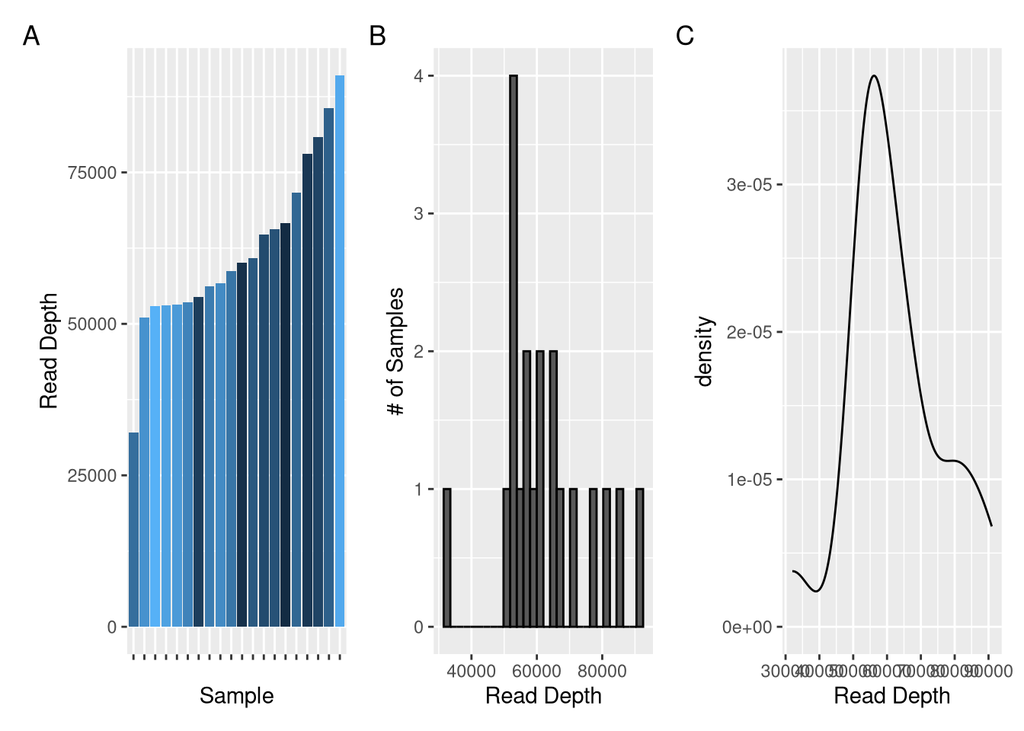

```r
# plot it as a bar plot
numSeq_bar_plot <-
  seqSums_df %>%
  ggplot(aes(x=reorder(names, TotalSeqs), y = TotalSeqs,
             fill = cheese_id)) +
  geom_bar(stat = "identity") +
  theme(axis.text.x = element_blank()) +
  labs(y = "Read Depth", x = "Sample") +
  theme(legend.position = "none")

# histogram
numSeq_hist_plot <-
  seqSums_df %>%
  ggplot(aes(x= TotalSeqs, fill = cheese_id)) +
  geom_histogram(color = "black") +
  labs(y = "# of Samples", x = "Read Depth") +
  theme(legend.position = "bottom")

# Density plot
numSeq_density_plot <-
  seqSums_df %>%
  ggplot(aes(TotalSeqs, fill = cheese_id)) +
  geom_density(alpha = 0.5) +
  labs(x = "Read Depth") +
  theme(legend.position = "none")

# Put it all together
numSeq_bar_plot + numSeq_hist_plot + numSeq_density_plot +
  plot_annotation(tag_levels = "A")
```

What can you conclude about your sequencing depths? What are your sample distributions? Do you have “enough” reads? Are there any samples that should be removed at this step?

I am more concerned about all of my metadata not having any data…I should have picked a different paper.

# Remove samples with few reads

I think all of the sequences are fine depth wise, so I will not be removing any samples.

# 9. Save output

## Raw Preprocessed Phyloseq Object

```r
#change object name so that it matches Mar's workflow
raw_preprocessed_physeq <-
  noChlorosMitos_physeq

save(raw_preprocessed_physeq, file = "data/03_PreProcessing/raw_preprocessed_physeq.RData")
```

# Final info for Reproducibility

## Check render rime

```r
end_time <- Sys.time()
end_time
```

```
## [1] "2025-03-27 21:54:09 EDT"
```

```r
elapsed_time <- round((end_time - start_time), 3)
elapsed_time
```

```
## Time difference of 3.497 secs
```